# Comunicação Rural e Metodologias Participativas · Da Extensão à Comunicação Dialógica

Extensão Rural

Prof. Dr. Luiz Diego Vidal Santos

## Abertura Visão Geral da Aula

Roteiro da aula Tópicos principais

- 1 Extensão Rural e Comunicação
- 2 Transição Paradigmática
- 3 Freire: Extensão ou Comunicação?
- 4 Andragogia e Abordagens Sistêmicas
- 5 Métodos Participativos (DRP, ARP, ECA)

Objetivo da aula Comunicação dialógica e prática

Compreender a transição da extensão difusionista para a comunicação dialógica e participativa, com base em Paulo Freire, na andragogia e nos métodos participativos.

Paulo Freire Andragogia DRP · ARP · ECA

Do monólogo técnico da transferência de pacotes à escuta ativa e à construção compartilhada do conhecimento.

# Da Difusão à Comunicação Dialógica

## Difusionismo A Extensão Rural e a Comunicação Linear

Abordagem difusionista inicial Fluxo unilateral

A extensão rural nas fases iniciais foi caracterizada por uma abordagem **difusionista**:

- Fluxo de informações **unilateral** (extensionista → agricultor)
- Mera ferramenta de implementação de tecnologias
- Abordagem “do **topo para baixo**” (Peixoto, 2008)

Assimetria comunicacional Comunicação linear

Comunicação **linear**, baseada na posse absoluta do conhecimento pelo extensionista.

**Exemplo histórico:** atuação da Associação Americana para o Desenvolvimento Econômico e Social (**AIA**).

No modelo linear, o erro ou a não adoção são imputados ao agricultor, ignorando a inadequação das mensagens e das tecnologias ao contexto local.

## Transição A Transição Paradigmática para o Diálogo

Via de mão dupla Comunicação dialógica

Um avanço significativo emergiu com a transição da **mera difusão** para uma **comunicação dialógica e participativa**, assegurando fluxo em **via de mão dupla**.

Valorização do sujeito Saberes e interesses locais

A comunicação participativa promove a incorporação efetiva da **sabedoria e experiência local** do agricultor e dos seus **interesses**.

**Princípio da reciprocidade:** Extensionista e agricultor tornam-se **aprendizes e educadores simultâneos**.

## Freire/DRP Freire: Extensão ou Comunicação?

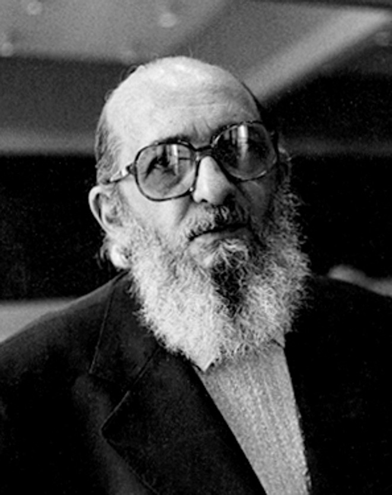

Retrato de Paulo Freire em 1977.

Paulo Freire (1977) Slobodan Dimitro · CC-BY-SA 3.0

Crítica ao termo “extensão” Comunicação ou Extensão (1980)

O termo “extensão”, como verbo transitivo, **coisifica** o homem do campo.

**Campo associativo:** invasão cultural, messianismo, transmissão.

Proposta de Paulo Freire Articulação de saberes

O agrônomo deve se posicionar como **“comunicador”**, engajando-se em diálogo **bidirecional e participativo**. A comunicação torna-se um processo de **articulação de saberes** — construção conjunta de conhecimentos aplicados à realidade.

# Abordagens Sistêmicas, Andragogia e PNATER

## Teorias Abordagens Comunicacionais e Base Teórica

Nasce a perspectiva das **abordagens sistêmicas e participativas**, que transformaram o ato de extensão em **momentos de trocas de saberes**.

| Teoria | Autor | Foco |
| --- | --- | --- |
| **Extensão como Comunicação** | Paulo Freire | Diálogo bidirecional |
| **Educação Crítica Construtivista** | Jean Piaget | Construção do conhecimento |
| **Crítica Emancipatória** | José Libâneo | Autonomia do sujeito |
| **Andragogia** | Malcolm S. Knowles | Aprendizagem adulta |

## Andragogia Andragogia: Os Seis Princípios na ATER

A andragogia busca, a partir de **seis princípios**, estruturar uma ATER efetiva, participativa e centrada no aprendiz adulto (Knowles, 1980):

01 · Necessidade Interesses reais

Explorar interesses pessoais do produtor.

02 · Autonomia Autogestão

Promover capacidade de autogestão nas decisões.

03 · Experiência Saber acumulado

O saber do agricultor é recurso pedagógico fundamental.

04 · Motivação Mediação ativa

Técnicos atuam como agentes catalisadores.

05 · Orientação na realidade Contexto local

Ações que caibam na realidade da propriedade.

06 · Aplicabilidade Uso e propagação

Proposta real, que o produtor possa usar e propagar.

## Autonomia Andragogia, Autonomia e Abordagens Sistêmicas

Pedagogia da Autonomia Empoderamento pela comunicação

A andragogia e a pedagogia da autonomia destacam-se como imperativo de uma extensão que **empodera** os indivíduos a *“tornarem-se autores de suas próprias histórias”* (Freire, 1996), a partir da **comunicação** existente entre todas as partes.

Exige a seleção de **métodos e meios apropriados** para garantir a compreensão do público-alvo.

Abordagens sistêmicas Complexidade dos sistemas locais

A agricultura não opera em um **vácuo**: está entrelaçada com contextos **sociais, econômicos e ambientais**.

Essa multiplicidade alinha-se à ênfase de Knowles na **experiência de vida** do adulto, promovendo relacionamento mais **simétrico e colaborativo** entre extensionistas e agricultores.

## Política PNATER (Lei 12.188/10) como Comunicação

A **Lei 12.188/10 (PNATER)** enfatiza a necessidade de **comunicação eficaz** como meio de promover seus seis princípios norteadores.

01 · Equidade Inclusão social

Participação democrática das famílias agricultoras.

02 · Reconhecimento Respeito à diversidade

Valorização das identidades e saberes locais.

03 · Sustentabilidade Transição ecológica

Transição para agricultura de base ecológica.

04 · Economia Ocupação e renda

Geração de trabalho, renda e agregação de valor.

05 · Integração Pesquisa–ATER–Ensino

Articulação permanente entre conhecimento científico e empírico.

06 · Cooperação Atuação em redes

Trocas interinstitucionais e protagonismo comunitário.

# Metodologias Participativas e Novas Mídias

## Freire/DRP Comunicação Dialógica e Ferramentas do DRP

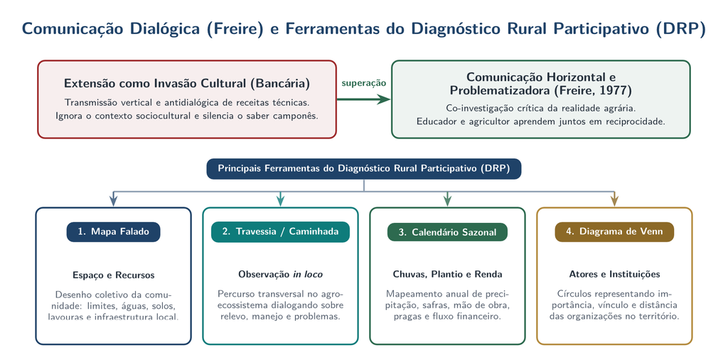

Diagrama da superação da extensão bancária pela comunicação horizontal freireana e principais ferramentas do DRP.

Comunicação Dialógica (Freire) e Ferramentas do Diagnóstico Rural Participativo (DRP) Mapa Falado, Travessia/Caminhada, Calendário Sazonal e Diagrama de Venn como práticas de co-investigação

## Métodos Métodos Participativos: ARP, DRP e ECA

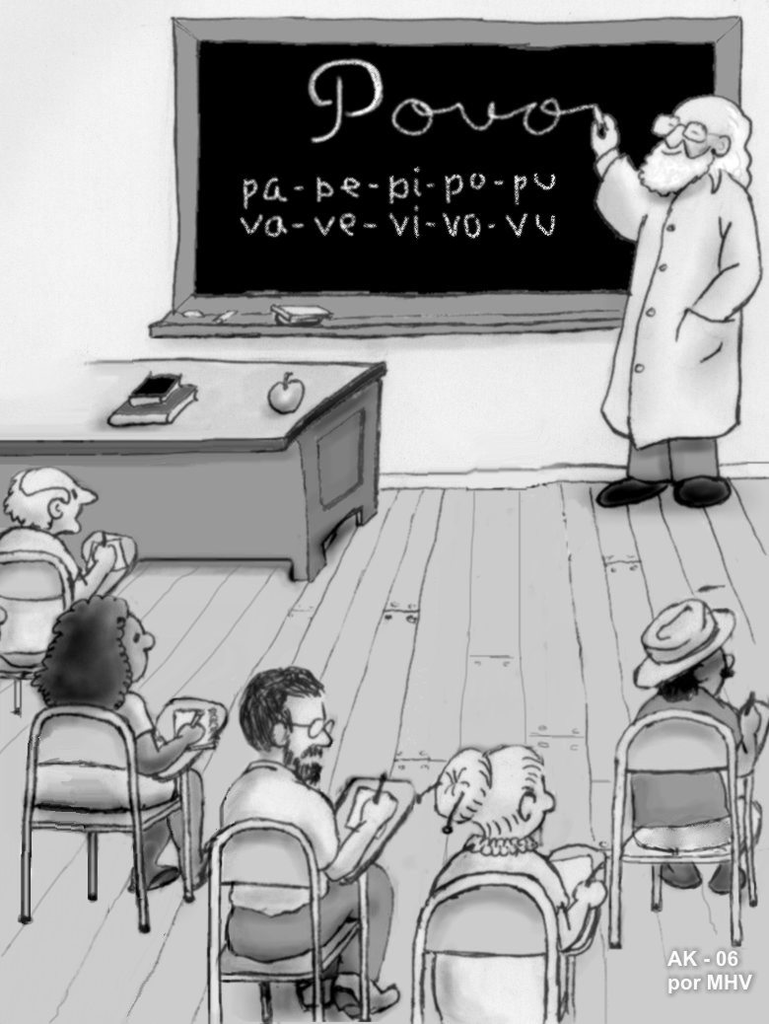

Ilustração do Método Paulo Freire em educação dialógica.

Método Paulo Freire — educação dialógica Ilustração de André Koehne · CC-BY-SA 3.0

| Método | Sigla | Descrição |
| --- | --- | --- |
| **Avaliação Rural Participativa** | ARP | Avaliação de necessidades e potencialidades |
| **Diagnóstico Rural Participativo** | DRP | Diagnóstico assertivo e direcionado |
| **Escolas de Campo para Agricultores** | ECA | Aprendizado prático no campo |

Facilitam o **diálogo** e a **tomada de decisão compartilhada**, incorporando na prática rural os princípios freireanos e andragógicos.

## Prática Aplicação Prática dos Métodos Participativos

**Possibilidades operacionais** para condução qualificada de processos participativos com grupos rurais:

**1. Diagnósticos assertivos (ex.: DRP):** direcionados ao perfil concreto da comunidade e do agroecossistema.

**2. Programação clara:** permitir que os participantes expressem seus interesses antes da oficina ou encontro.

**3. Capacitar grupos com interesse comum:** redução de ruídos comunicacionais e maior engajamento coletivo.

**4. Recursos didáticos apropriados:** materiais visuais e práticos para reduzir dificuldades de materialização.

**5. Ouvir ativamente:** ouvir o máximo possível, tomar anotações e compreender necessidades reais antes de propor soluções.

## Mídias Marketing Rural e Novas Mídias na Extensão

Comercialização e território Marketing Rural

Estratégias de comercialização de produtos e serviços voltados ao campo:

- **Marketing de insumos:** sementes, fertilizantes, máquinas
- **Marketing de produtos:** comercialização agrícola, feiras, mercados institucionais (PAA, PNAE)
- **Marketing territorial:** indicações geográficas, selos de origem
- **Marketing social:** campanhas educativas no campo

Revolução digital no campo Novas Mídias na Extensão

Novos canais transformaram a comunicação rural:

- **WhatsApp** como ferramenta de articulação entre agricultores e extensionistas
- **YouTube** — canais de manejo agrícola com milhões de acessos
- Redes sociais de cooperativas e feiras agroecológicas
- **Podcasts** rurais e agronômicos

O desafio é garantir que as novas mídias sirvam à comunicação **dialógica**, não à mera difusão publicitária (Freire, 1979).

# Síntese e Referências

## Síntese Conclusão: A Comunicação como Elemento Crucial

Uma comunicação eficaz emerge como elemento **crucial** para o sucesso do novo paradigma da extensão rural brasileira.

01 · Sustentabilidade Catalisador

Atua como **catalisador** para o desenvolvimento rural sustentável.

02 · Protagonismo Empoderamento

Promove o **empoderamento** das comunidades rurais.

03 · Reciprocidade Troca de saberes

Transforma a extensão em **troca de saberes** contextualizados.

04 · Postura profissional Comunicador

O extensionista atua como **comunicador**, não como transmissor.

## Referências Referências Bibliográficas e Marcos Legais

Legislação e fundamentos freireanos Normas e pedagogia dialógica

- Brasil. Lei 12.188/2010 — PNATER (2010)
- Freire, P. *Extensão ou Comunicação* (1979; 1980)
- Freire, P. *Pedagogia da Autonomia* (1996)

Andragogia e extensão rural Referências complementares

- Knowles, M. S. *A prática moderna da educação de adultos* (1980)
- Landini, F. *Problemas enfrentados por extensionistas* (2015)
- Peixoto, M. et al. *Extensão rural no Brasil* (2008)
- Piaget, J.; Libâneo, J. C. Abordagens construtivistas e emancipatórias